# 231204_redox_corrections

2023-12-04

### Goal

Detail the steps used to go from raw redox values collected by SWAP sensors during TEMPEST to final Eh values to be used on poster / in paper.

### Raw data

I know it gets old looking at time-series, but I’d like to present ALL the data in completely raw format first, so that we’re all starting at 0. Note the dashed vertical line below marks the start of the last sensors we got online (seawater plot) so that we’re starting a consistent datetime origin across plots:

#### Freshwater

Behavior looks very similar between reference probes (ra and rb).

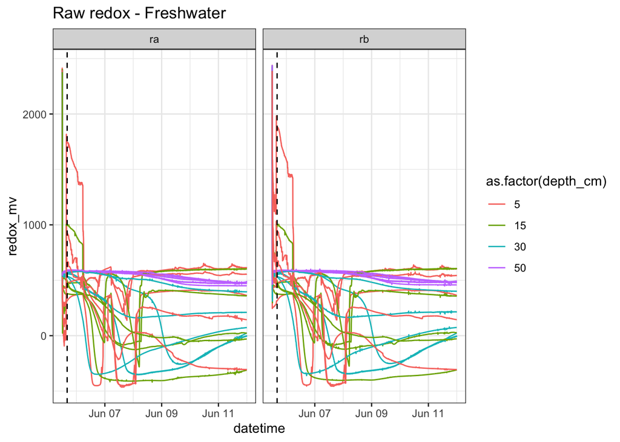

#### Estuarine

As with Freshwater, we see similar behavior between reference probes.

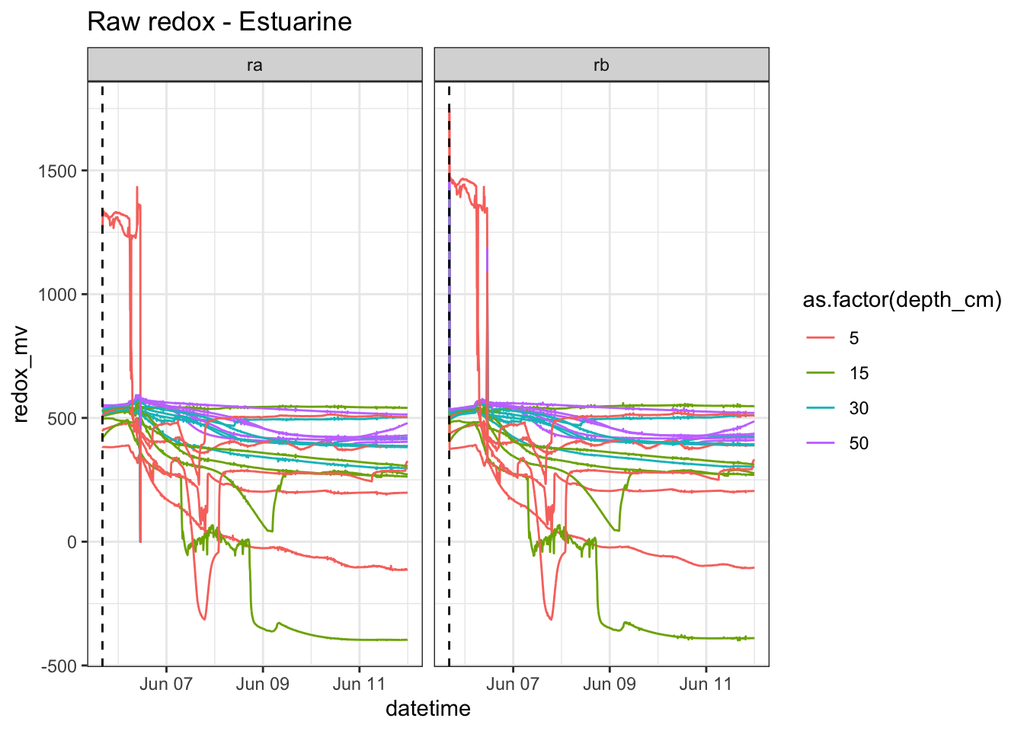

#### Control

And this is where things get funky. Based on behavior in the other two plots, and particularly at depth, we don’t see clear diurnal signals in the data. While Control might be more susceptible due to thinner canopy, I’m hard-pressed to believe that daily cycles of 200 mV is real, and happening consistently at all depths.

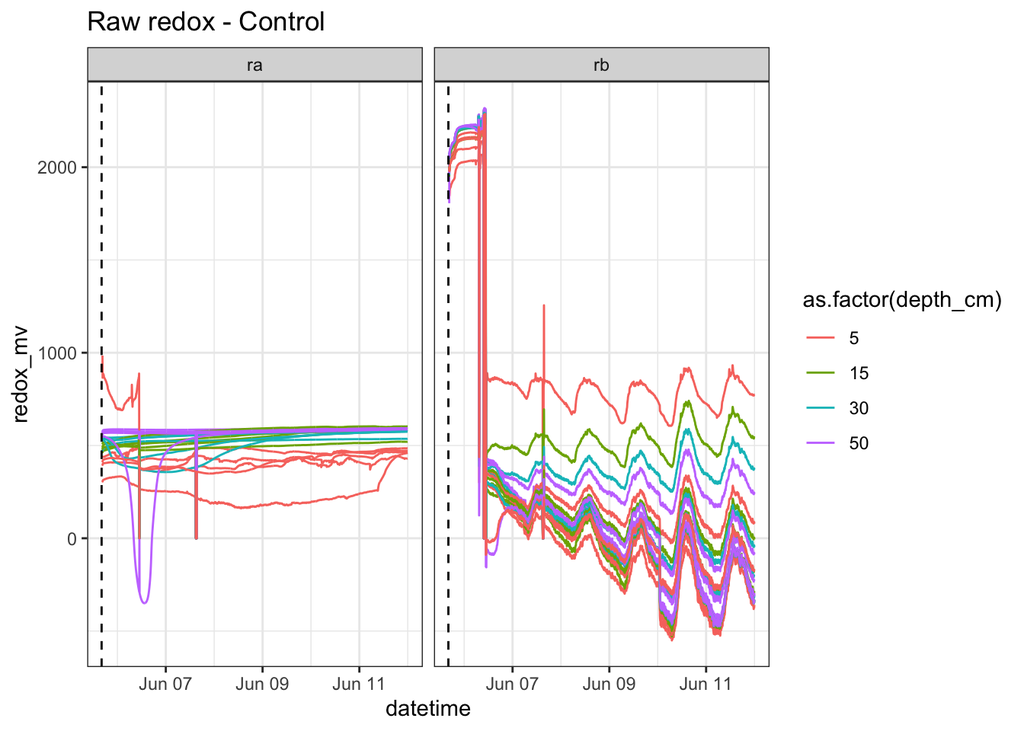

**Decision: Use “ra” as reference**

### Binning

**Decision: Include all sensors, use means, and scrub then gap-fill 0s**

#### Binned but with errors

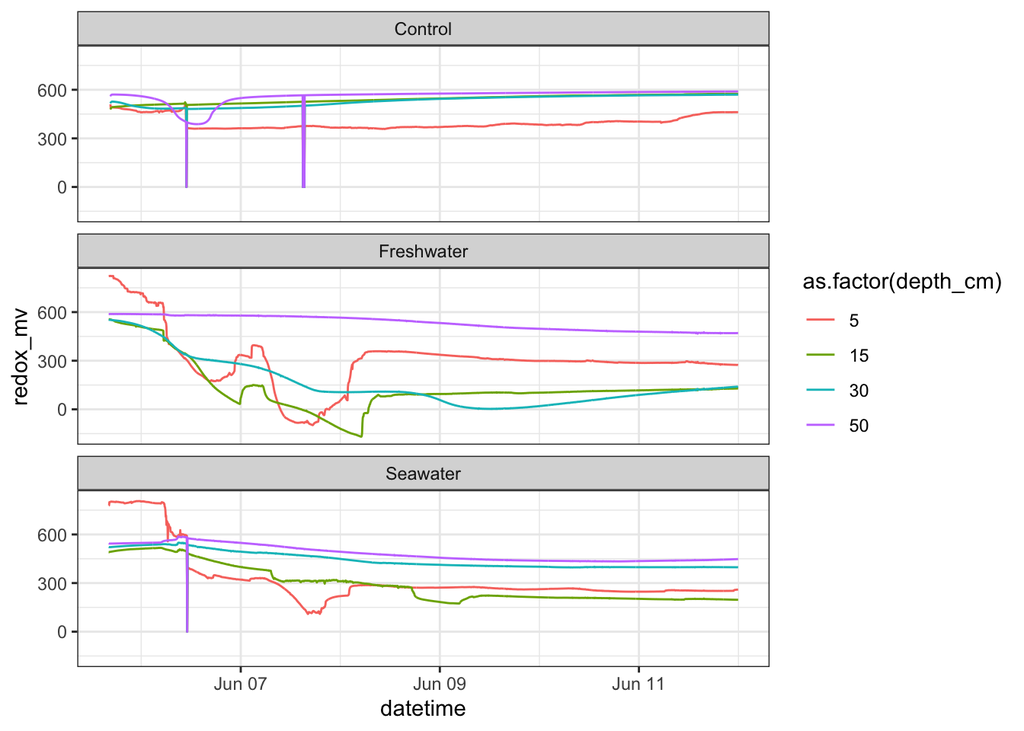

#### Binned with errors gap-filled

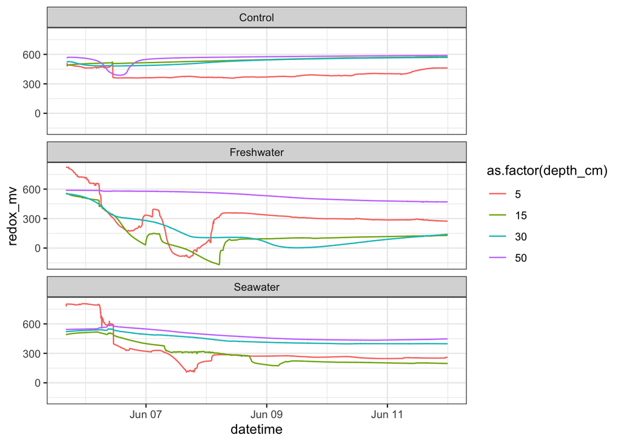

### Corrections

Based on my nascent understanding of redox, there are several potential corrections, including

- changes in temperature
- soil pH
- conversion to Eh units

I’ll do the correction for temperature at the same time as the conversion to SHE using $Eh=ORP-0.718*T+224.41$. This equation was pulled from [Fausto’s pre-print](https://www.biorxiv.org/content/10.1101/2023.06.12.544684v1.full.pdf) (see L154) which he applied to both soil and water redox sensors.

**Decision: use Fausto’s correction equation for final units**

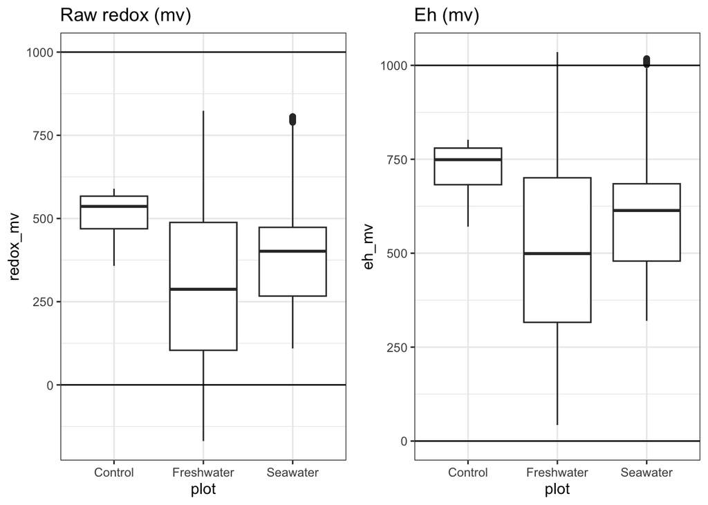

### Questions for y’all

1. What corrections am I missing that need to be incorporated?
2. Does the equation used to correct make sense?
3. Smell test: what feels wrong and what feels right?